# Reproducible Research Peer Assessment 1

Brian Ostrovsky

December 4, 2014

## Loading and preprocessing data

The Activity Monitoring Dataset was downloaded from: https://d396qusza40orc.cloudfront.net/repdata%2Fdata%2Factivity.zip on December 4th at 9:56am PST

The variables included in this dataset are:

- steps: Number of steps taking in a 5-minute interval (missing values are coded as NA)
- date: The date on which the measurement was taken in YYYY-MM-DD format
- interval: Identifier for the 5-minute interval in which measurement was taken

```r
activity <- read.csv("~/Desktop/Reproducable Research/activity.csv")
activity$date <- as.Date(activity$date, "%Y-%m-%d")
```

## What is the mean total number of steps taken per day?

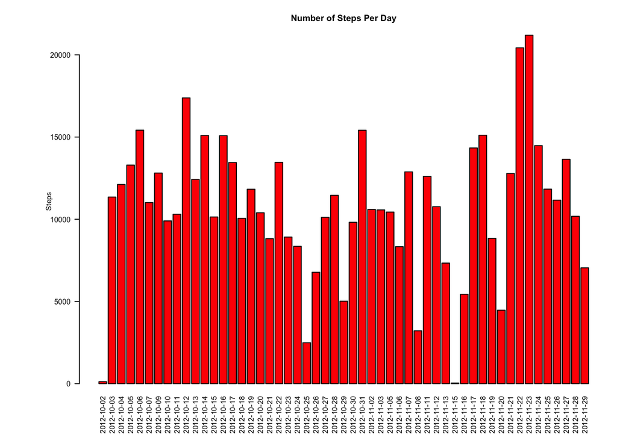

```r
totalSteps  <- aggregate(steps~date, data = activity, sum, na.rm = TRUE)
par(mar=c(6,9,4,1), cex=.5, las=2)
histogram<-barplot(totalSteps$steps, names.arg = totalSteps$date,ylab="          Steps", main="Number of Steps Per Day", col="red")
```

```r
meanSteps  <-  mean(totalSteps$steps)
medianSteps <-  median(totalSteps$steps)
```

The mean number of steps is 10766 and the median is 10765.

## What is the average daily activity pattern?

This plot averages the intevals across each of the days in the data set to get to an average of daily activity

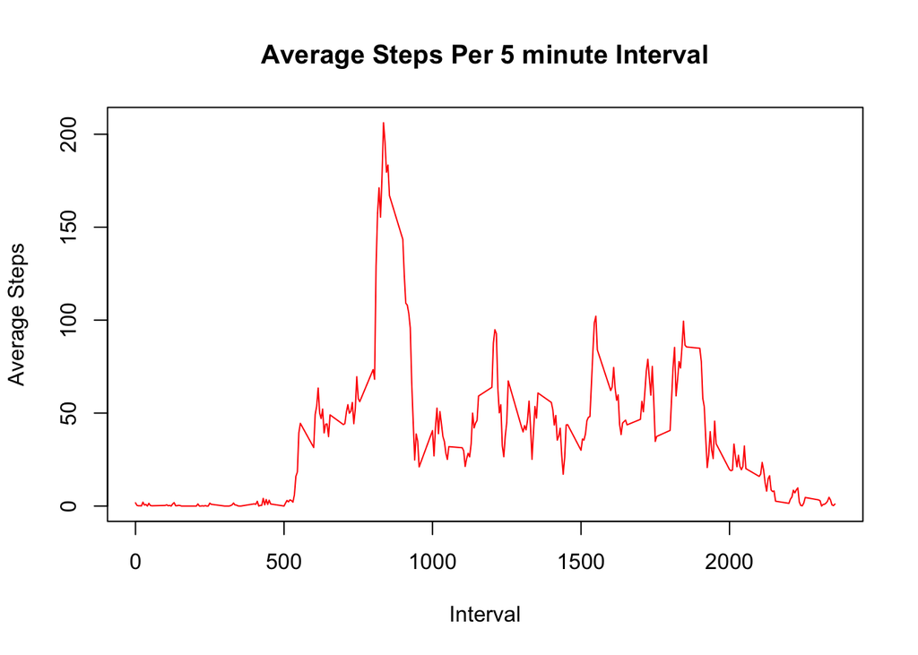

```r
aveInterval <- aggregate(steps ~ interval, activity, mean)
plot(aveInterval, type="l", xlab="Interval", ylab="Average Steps", main="Average Steps Per 5 minute Interval", col="red")
```

Calculating the maximum interval of the average day:

```r
aveInterval$interval[which.max(aveInterval$steps)]
```

```
## [1] 835
```